# An Analysis on my 2023 Fantasy Football League (So Far)

Finally, this last graph was made solely for my friends and I so that we can laugh at the thought of who is getting wrecked this year in fantasy. Take a look below for more details 😄

**Warning**

Team TP, you might want to look away for for this one…

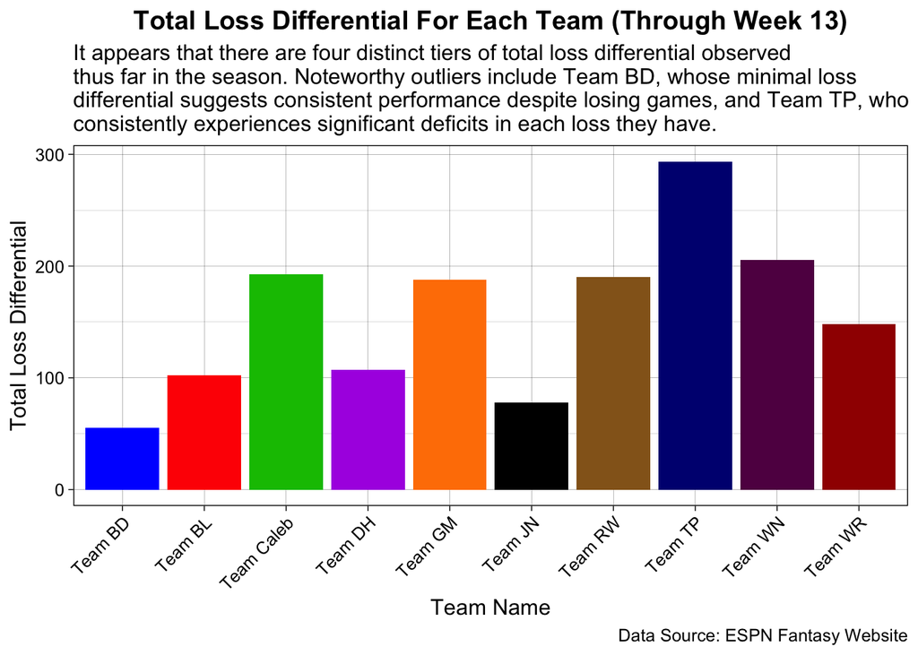

```r
# graph for worst loss differential

# grab difference of scores
matchups_diff = matchups |>
  # find difference of scores
    mutate(Difference = Score1 - Score2)

# get team with lower score
matchups_diff$LowerScoreName = ifelse(matchups_diff$Difference < 0, matchups_diff$Name1, matchups_diff$Name2)

# get abs of difference and plot
matchups_diff |>
  # absolute the difference
  mutate(Difference = abs(Difference)) |>
  # group by team
  group_by(LowerScoreName) |>
  # get sum of differences for each team
  summarise(sum_diff = sum(Difference)) |>
  # init plot
  ggplot(aes(x = LowerScoreName, y = sum_diff, fill = LowerScoreName)) +
  # geom bar for each team
  geom_col(position = "dodge") +
  # add colors
  scale_fill_manual(values = paletteer_d("ggprism::colors", 12)) +
  # change to linedraw
  theme_linedraw() +
  # add theme
  theme(axis.text.x = element_text(angle = 45, hjust = 1),
    text = element_text(size = 12),
    plot.title = element_text(face = "bold", hjust = 0.5)) +
  # add labels
  labs(
    x = "Team Name",
    y = "Total Loss Differential",
    title = "Total Loss Differential For Each Team (Through Week 13)",
    fill = "Team Name",
    caption = "Data Source: ESPN Fantasy Website",
    subtitle = str_wrap("It appears that there are four distinct tiers of total loss differential observed thus far in the
                         season. Noteworthy outliers include Team BD, whose minimal loss differential suggests consistent
                        performance despite losing games, and Team TP, who consistently experiences significant deficits
                        in each loss they have.", width = 85)) +
  # get rid of legend
  guides(fill = "none")
```

This plot is expressing the worst Loss Differential… so sorry Team TP 😅 It’s not looking good for you! One thing to note is this is not counting how much you win, it is solely taking the weeks you lose and finding the differential between you and your opponent’s team score.

## Final Thoughts

Ultimately, I had a really fun time doing this analysis and writing this blog! Looking forward to updating the results as the weeks go on, and to see who will be my league’s crowned chamption this year 🥳

To summarize a bit of what my analysis consisted of - I analyzed data from my 2023 Fantasy Football League. I found interesting trends in the weekly match-ups, such as typically when a team over-performs they will get the W (but not always) or some teams went through a rough stretch of weeks. I also showed how RBs and WRs are typically the positions that score the most points, with other positions being more team dependent (aka you have the one good TE in the league). Our league is pretty tight this year in terms of rankings, so it was hard to see that a certain trend in the data leads you to be the best team. However, I think as the weeks go on that will certainly become more clear. My goal is to do more of a statistical analysis when the season is complete in order to step up my game for next year’s fantasy football season! 😄

## Functions Used

dplyr/tidyr:

1. filter: filter rows based on conditions
2. select: select specific columns
3. summarise: calculate summary statistics
4. mutate: create or modify a column
5. group_by: group data based on variables
6. inner_join: merge two datasets on key values

ggplot2:

1. geom_line: line plot
2. geom_point: points on line plot
3. geom_bar: bar plot
4. geom_col: column plot
5. geom_violin: violin plot
6. geom_boxplot: boxplot within violin plot

## References

[1]

J. Mannelly, “Analyzing your fantasy football season with python.” https://jman4190.medium.com/analyzing-your-fantasy-football-season-with-python-8c228262eae9.

[2]

S. Stimson, “Checking ESPN fantasy football projections with python.” https://stmorse.github.io/journal/espn-fantasy-projections.html.

[3]

ESPN, “Fantasy football for beginners: How to play fantasy football 2022.” https://www.espn.com/fantasy/football/story/_/id/34389554/fantasy-football-beginners-how-play-fantasy-football-2022, 2022.

[4]

“ESPN fantasy football github.” https://github.com/tbryan2/espnfantasyfootball.

[5]

“ESPN fantasy football.” https://www.espn.com/fantasy/football/.